# Statistical Methods in Financial Engineering - Risk Management Project

Chloe Morin-Leclerc, Felix-Antoine Groulx, Denis Genest, Thien Duy Tran

décembre 12, 2019

# Part I: Project Guidelines

## Context

You work as a quantitative analyst for a large investment bank. You and your team are responsible for challenging the models used by traders and risk managers. You work with R and love reproducible research. All your files are written in Rmarkdown or R notebook.

You can watch the introductory video on Rmarkdown to help you build properly the R file. Moreover, you use GitHub with your team. You’ll build a dedicated project for the tasks below and use RStudio with GitHub extensively. You also use Loom to share your findings with other teams in the investment bank.

## Learning Objectives

1. Content (scientific rigor, concepts, creativity).
2. Choose the right tools.
3. Implement the steps correctly.
4. Come up with innovative solutions.

## Form: Coding, Collaboration and Presentation

1. Build RStudio project with proper folder structure and Rmarkdown/nootebook file to reproduce your results.
2. Program with state-of-the-art coding standards.
3. Use GitHub repository for collaborative research.
4. Use Loom video for presenting your results.

## Objective

The objective of this project is to implement the risk management framework used for estimating the risk of a book of European call options by taking into account risk drivers such as the underlying asset and the implied volatility of the options.

# Part II: Data

## Loading the Data

The first step is to load the database ‘Market’. ‘Market’ is a list of 5 elements: S&P500 index prices, VIX values, the term structure of interest rates, and traded call and put options information. To make sure this code can run on any platform, we use the library ‘here’.

```r
# install.packages("here")
library("here")

# Load the data
load(file = here("Data", "Market.rda"))

# Load the functions
source(file = here("Functions", "price_call.r")) # Prices calls using the Black-Scholes formula
source(file = here("Functions", "lin_inter.r"))  # Linear interpolation of the interest rates

# Assign data to different variables
vix       <- as.vector(Market$vix)
sp_500    <- as.vector(Market$sp500)
calls     <- as.vector(Market$calls)
puts      <- as.vector(Market$puts)

# Create a matrix 'rates' with two columns: maturities and risk-free rates
rates     <- matrix(data = NA, nrow = length(Market$rf), ncol = 2)
rates[,1] <- as.numeric((attributes(Market$rf))[[2]])
rates[,2] <- Market$rf

# Assign column names to 'rates'
colnames(rates) <- c("Maturities", "Risk-free Rates")
```

# Part III: Pricing a Portfolio of Options

The portfolio under consideration contains four options: K = 1600 and T-t = 20 days, K = 1650 and T-t = 20 days, K = 1750 and T-t = 40 days, and K = 1800 and T-t = 40 days. We assume that there is 250 days in a year and thus convert times to expiry in years by dividing by 250. We first create a matrix ‘book’ that contains information regarding the options in the portfolio.

```r
# Create matrix
book_1 <- matrix(data = NA, nrow = 4, ncol = 4)

# Assign names to columns
colnames(book_1) <- c("Quantity", "Call", "StrikePrice", "Maturity")

# Store initial values
book_1[1,] <- c(1, 1, 1600, 20 / 250)
book_1[2,] <- c(1, 1, 1650, 20 / 250)
book_1[3,] <- c(1, 1, 1750, 40 / 250)
book_1[4,] <- c(1, 1, 1800, 40 / 250)
```

The next step is to use the most recent underlying asset price and VIX value as well as the interpolated risk-free rates to compute the value of each option in the portfolio that we store in the variable ‘call_price’. The value of the portfolio of options is simply the sum of each option’s value. To do this, we use two functions described below.

1. ‘lin_inter’: Takes as input a maturity in years (360-day basis) and outputs the associated rate. Uses linear interpolation with the given term structure.
2. ‘price_call’: Takes as inputs the underlying asset price, the option strike price, the risk-free rate, the volatility, and the maturity. Uses Black-Scholes model to price call options.

```r
# Number of observations
n_obs <- length(sp_500)

# Convert 250-day basis year in 360-day basis year
m_1 <- unique(book_1[,4])[1] * (250 / 360)
m_2 <- unique(book_1[,4])[2] * (250 / 360)

# Interpolated interest rates
r_1 <- lin_inter(m_1)
r_2 <- lin_inter(m_2)

# Latest underlying asset price (spot price)
S_1 <- sp_500[n_obs]

# Latest VIX value
vol_1 <- vix[n_obs]

# Strike prices
K <- book_1[,3]

# Maturities
M <- book_1[,4]

# Initialize a vector to store call prices
call_price <- c(rep(NA, 4))

# Compute the option values and store them in 'call_price'
call_price[1] <- price_call(S_1, K[1], r_1, vol_1, M[1])
call_price[2] <- price_call(S_1, K[2], r_1, vol_1, M[2])
call_price[3] <- price_call(S_1, K[3], r_2, vol_1, M[3])
call_price[4] <- price_call(S_1, K[4], r_2, vol_1, M[4])

# Compute the price of the portfolio and store it in 'PF_price_1'
PF_price_1 <- sum(call_price)
```

```
The value of the portfolio of European call options is 156.21$.
The options are worth respectively 87.31$, 47.52$, 15.10$, 6.28$.
```

It is not surprising to see that the value of the first option is higher than the value of the second option. Indeed, since the strike price is lower for the first option, the first option is deeper ITM than the second option and it should therefore have a higher price. The same reasoning applies to the third and fourth options.

# Part IV: One Risk Driver and Gaussian Model

We now want to estimate the value-at-risk (VaR) and the expected shortfall (ES) of this portfolio of options over the course of the following week. To do so, we must first compute the underlying asset log returns.

```r
# Daily underlying asset log returns
log_return <- diff(log(sp_500))
```

Next, we assume that the underlying asset log returns follow a normal distribution. The normal distribution parameters can be found by computing the empirical mean and standard deviation of the underlying asset daily log returns.

```r
# Number of log returns
n_ret <- length(log_return)

# Calibration
mu_hat <- mean(log_return)
s2_hat <- mean((log_return - mu_hat)^2) * (n_ret / (n_ret - 1))
sd_hat  <- s2_hat^0.5

# Store parameters in 'theta_1'
theta_1 <- c(mu_hat, sd_hat)
```

Now that we have estimated the parameters of the underlying asset return log returns, we can run a simulation of the underlying asset price one week ahead by generating normally distributed IID shocks with mean ‘mu_hat’ and standard deviation ‘sd_hat’. Since we found the distribution parameters using daily log returns, we generate five shocks per simulation and sum these shocks to obtain the overall shock over one week. We fix the size of the simulation to 10 000.

```r
# Number of simulation
H <- 10000

# Number of days between now and the forecast horizon
t <- 5

# Set seed for generating pseudo-random numbers
set.seed(4321)

# Store in 'sim_ret_1' normally distributed IID shocks with mean 'mu_hat' and standard deviation 'sd_hat'
sim_ret_1 <- matrix(rnorm(t * H, mean = theta_1[1], sd = theta_1[2]), nrow = H, ncol = t)
```

In order to obtain the underlying asset price one week from now, we simply have to compute the exponential sum of the five daily normally distributed IID shocks per trajectory and multiply by the latest underlying asset price. The last thing we need to modify is the risk-free rate for the remaining life of the option. The strike price does not change over the option life and the volatility is assumed to be constant.

```r
# Compute the price of the underlying asset one week from now
S_2 <- S_1 * exp(rowSums(sim_ret_1))

# Update the risk-free rate (360-day basis year)
r_3   <- lin_inter(m_1 - t / 360)
r_4   <- lin_inter(m_2 - t / 360)

# Initialize a matrix to store call prices (10 000 rows (1 per simulation), 4 columns (1 per option))
call_price_2 <- matrix(NA, nrow = H, ncol = 4)

# Loop through 10 000 simulations and price each call option
for (i in 1:10000){
  call_price_2[i,1] <- price_call(S_2[i], K[1], r_3, vol_1, M[1] - t / 250)
  call_price_2[i,2] <- price_call(S_2[i], K[2], r_3, vol_1, M[2] - t / 250)
  call_price_2[i,3] <- price_call(S_2[i], K[3], r_4, vol_1, M[3] - t / 250)
  call_price_2[i,4] <- price_call(S_2[i], K[4], r_4, vol_1, M[4] - t / 250)
}
```

For each replication, we can compute the value of the portfolio of options by summing the value of the four call options. Recall that we want to estimate the VaR and the ES of this portfolio of options over the course of the following week. Therefore, for each replication, we must compute a P&L by discounting at the risk-free rate the value of the portfolio of options one week from now and subtracting the value of the portfolio observed today.

```r
# Compute the price of the portfolio for each replication and store it in 'PF_price_2'
PF_price_2 <- rowSums(call_price_2)

# Compute the risk-free rate for a period of 5 days (360-day basis year)
r_PL <- lin_inter(t / 360)

# Compute the P&L
PL_1 <- PF_price_2 * exp(-(t / 360) * r_PL) - PF_price_1
```

The last step is to compute the VaR and the ES of the portfolio of options P&L distribution. In order to do so, we sort the P&L values in ascending order and identify the (1-alpha)-quartile of the distribution for the VaR, where alpha is the risk level (in our case, 0.95). The ES is simply the mean of the P&L values smaller than the VaR.

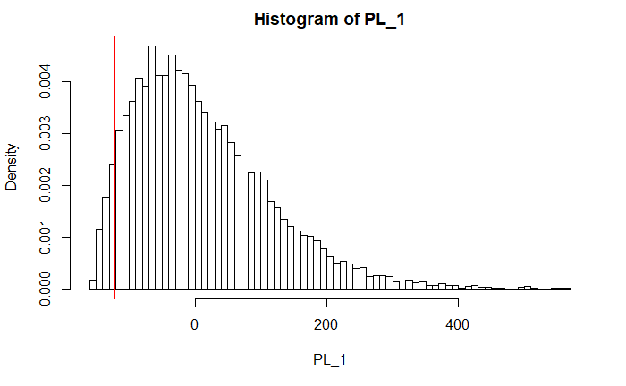

```r
# Set alpha to a desired significance level
alpha <- 0.95

# Compute the VaR and the ES of the P&L distribution
VaR_1 <- sort(PL_1)[(1 - alpha) * H]
ES_1  <- mean(sort(PL_1)[1:((1 - alpha) * H)])

# Plot an histogram
hist(PL_1, nclass = round(10 * log(length(PL_1))), probability = TRUE)

# Add a vertical line to show the VaR
abline(v   = quantile(PL_1, probs = (1 - alpha)),
       lty = 1,
       lwd = 2.5,
       col = "red")
```

```
The value at risk at alpha = 0.95 is -121.67$.
The expected shortfall at alpha = 0.95 is -134.17$.
```

# Part V: Two risk drivers and Gaussian model

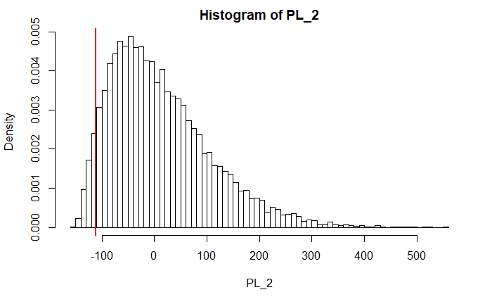

```r
# install.packages("MASS")
library("MASS")

# Daily VIX log returns
vix_return <- diff(log(vix))

# Store underlying asset log returns and VIX log returns in 'rets'
rets     <- matrix(NA, nrow = n_ret, ncol = 2)
rets[,1] <- log_return
rets[,2] <- vix_return

# Calibration
mu_hat <- colMeans(rets)
sg_hat <- ((n_ret - 1) / n_ret) * cov(rets)

# Store parameters in 'theta_2'
theta_2 <- list(mu = mu_hat, sigma = sg_hat)

# Initialize the array 'sim_ret_2'
sim_ret_2 <- array(data = NA, dim = c(H, 2, t))

# Set seed for generating pseudo-random numbers
set.seed(4321)

# Store in 'sim_ret_2' daily shocks from a multivariate normal distribution with parameters 'theta_2'
for (i in 1:t) {
  sim_ret_2[,,i] <- mvrnorm(n = H, mu = theta_2$mu, Sigma = theta_2$sigma)
}

# Initialize two vectors that contain the underlying asset price and the VIX value one week from now
S_3   <- rep(NA, H)
vol_3 <- rep(NA, H)

# Compute the underlying asset price and the VIX value one week from now
for (i in 1:H) {
  S_3[i]   <- S_1 * exp(sum(sim_ret_2[i,1,]))
  vol_3[i] <- vol_1 * exp(sum(sim_ret_2[i,2,]))
}

# Initialize a matrix to store call prices (10 000 rows (1 per simulation), 4 columns (1 per option))
call_price_3 <- matrix(NA, nrow = H, ncol = 4)

# Loop through 10 000 simulations and price each call option
for (i in 1:10000){
  call_price_3[i,1] <- price_call(S_3[i], K[1], r_3, vol_3[i], M[1] - t / 250)
  call_price_3[i,2] <- price_call(S_3[i], K[2], r_3, vol_3[i], M[2] - t / 250)
  call_price_3[i,3] <- price_call(S_3[i], K[3], r_4, vol_3[i], M[3] - t / 250)
  call_price_3[i,4] <- price_call(S_3[i], K[4], r_4, vol_3[i], M[4] - t / 250)
}

# Compute the price of the portfolio for each replication and store it in 'PF_price_3'
PF_price_3 <- rowSums(call_price_3)

# Compute the P&L
PL_2 <- PF_price_3 * exp(-(t / 360) * r_PL) - PF_price_1

# Compute the VaR and the ES of the P&L distribution
VaR_2 <- sort(PL_2)[(1 - alpha) * H]
ES_2  <- mean(sort(PL_2)[1:((1 - alpha) * H)])

# Plot an histogram
hist(PL_2, nclass = round(10 * log(length(PL_2))), probability = TRUE)

# Add a vertical line to show the VaR
abline(v   = quantile(PL_2, probs = (1 - alpha)),
       lty = 1,
       lwd = 2.5,
       col = "red")
```

```
The value at risk at alpha = 0.95 is -111.15$.
The expected shortfall at alpha = 0.95 is -123.77$.
```

# Part VI: Two risk drivers and copula-marginal model

```r
# install.packages("copula")
library("copula")

# install.packages("fGarch")
library("fGarch")
library("timeDate")
library("timeSeries")
library("fBasics")

# Load the function
source(file = here("Functions", "nll_student.r")) # Computes the negative log-likelihood function

# Define an initial vector of parameters for the underlying asset log returns
theta_0 <- c(mean(log_return), sd(log_return), 10)

# Calibrate the student-t distribution on the underlying asset log returns
tmp <- optim(par = theta_0,
             fn = nll_student,
             method = "L-BFGS-B",
             lower = c(-Inf, 1e-5, 10),
             x = log_return)

# Store parameters in 'theta_3'
theta_3 <- tmp$par

# Define an initial vector of parameters for the VIX log returns
theta_0 <- c(mean(vix_return), sd(vix_return), 5)

# Calibrate the student-t distribution on the VIX log returns
tmp <- optim(par = theta_0,
             fn = nll_student,
             method = "L-BFGS-B",
             lower = c(-Inf, 1e-5, 5),
             x = vix_return)

# Store parameters in 'theta_3'
theta_4 <- tmp$par

# Compute 'U_1' and 'U_2' and combine these two variables in 'U'
U_1 <- pstd(log_return, mean = theta_3[1], sd = theta_3[2], nu = theta_3[3])
U_2 <- pstd(log_return, mean = theta_4[1], sd = theta_4[2], nu = theta_4[3])
U   <- cbind(U_1, U_2)

# Calibrate a Gaussian copula
C   <- normalCopula(dim = 2)
fit <- fitCopula(C, data = U, method = "ml")

# Set seed for generating pseudo-random numbers
set.seed(4321)

sim_U          <- rCopula(H * t, fit@copula)
sim_log_return <- qstd(sim_U[,1], mean = theta_3[1], sd = theta_3[2], nu = theta_3[3])
sim_vix_return <- qstd(sim_U[,2], mean = theta_4[1], sd = theta_4[2], nu = theta_4[3])

# Initialize the array 'sim_ret_3'
sim_ret_3 <- array(data = NA, dim = c(H, 2, t))

# Store in 'sim_ret_3' daily log returns for the underlying asset and the VIX
for (i in 1:t) {
  sim_ret_3[,,i] <- c(sim_log_return[(H * (i - 1) + 1):(H * i)], sim_vix_return[(H * (i - 1) + 1):(H * i)])
}

# Initialize two vectors that contain the underlying asset price and the VIX value one week from now
S_4   <- rep(NA, H)
vol_4 <- rep(NA, H)

# Compute the underlying asset price and the VIX value one week from now
for (i in 1:H) {
  S_4[i]   <- S_1 * exp(sum(sim_ret_3[i,1,]))
  vol_4[i] <- vol_1 * exp(sum(sim_ret_3[i,2,]))
}

# Initialize a matrix to store call prices (10 000 rows (1 per simulation), 4 columns (1 per option))
call_price_4 <- matrix(NA, nrow = H, ncol = 4)

# Loop through 10 000 simulations and price each call option
for (i in 1:10000){
  call_price_4[i,1] <- price_call(S_4[i], K[1], r_3, vol_4[i], M[1] - t / 250)
  call_price_4[i,2] <- price_call(S_4[i], K[2], r_3, vol_4[i], M[2] - t / 250)
  call_price_4[i,3] <- price_call(S_4[i], K[3], r_4, vol_4[i], M[3] - t / 250)
  call_price_4[i,4] <- price_call(S_4[i], K[4], r_4, vol_4[i], M[4] - t / 250)
}

# Compute the price of the portfolio for each replication and store it in 'PF_price_4'
PF_price_4 <- rowSums(call_price_4)

# Compute the P&L
PL_3 <- PF_price_4 * exp(-(t / 360) * r_PL) - PF_price_1

# Compute the VaR and the ES of the P&L distribution
VaR_3 <- sort(PL_3)[(1 - alpha) * H]
ES_3  <- mean(sort(PL_3)[1:((1 - alpha) * H)])

# Plot an histogram
hist(PL_3, nclass = round(10 * log(length(PL_3))), probability = TRUE)

# Add a vertical line to show the VaR
abline(v   = quantile(PL_3, probs = (1 - alpha)),
       lty = 1,
       lwd = 2.5,
       col = "red")
```

[output not shown]

```
The value at risk at alpha = 0.95 is -112.92$.
The expected shortfall at alpha = 0.95 is -127.30$.
```

# Part VII: Volatility Surface

```r
#install.packages("rgl")
library("rgl")

# Load the functions
source(file = here("Functions", "vol_surface.R"))   # Implied volatility of an option
source(file = here("Functions", "vol_calibrate.r")) # Sum of absolute deviations of implied volalities

# Count the number of traded options
nb_opts <- nrow(Market$calls) + nrow(Market$puts)

# Build a matrix that contains the information relevant to traded call and put options
mkt_vol <- matrix(NA, nrow = nb_opts, ncol = 4)

# Assign names to columns
colnames(mkt_vol) <- c("S", "K", "tau", "IV")

# Latest underlying asset price (spot price)
mkt_vol[,1] <- t(t(rep(sp_500[n_obs], nb_opts)))

# Strike price of call options
mkt_vol[1:nrow(Market$calls),2] <- Market$calls[,1]

# Strike price of put options
mkt_vol[(nrow(Market$calls)+1):nb_opts,2] <- Market$puts[,1]

# Time to expiry of call options
mkt_vol[1:nrow(Market$calls),3] <- Market$calls[,2]

# Time to expiry of put options
mkt_vol[(nrow(Market$calls)+1):nb_opts,3] <- Market$puts[,2]

# Implied volatility of call options
mkt_vol[1:nrow(Market$calls),4] <- Market$calls[,3]

# Implied volatility of put options
mkt_vol[(nrow(Market$calls)+1):nb_opts,4] <- Market$puts[,3]

# Set a vector of initial values of a1, a2, a3, and a4
x0 <- c(0.2, 1, 1, 0.1)

# Calibrate the volatility surface on traded call and put options
tmp <- optim(par = x0,
             fn = vol_calibrate)

# Store parameters in 'theta_vol'
theta_vol <- tmp$par

# Generate a sequence of strike price and time to expiry
x1 <- sp_500[n_obs] * seq(0.5, 1.5, (1.5 - 0.5) / 1000)
x2 <- seq(0.01, 2, (2 - 0.01) / 1000)

# Generate al possible combinations of 'x1' and 'x2'
x3 <- expand.grid(x1,x2)

# Compute the implied volatility for each combination
y  <- vol_surface(sp_500[n_obs], x3[,1], x3[,2], theta_vol[1], theta_vol[2], theta_vol[3], theta_vol[4])

# Create a 3D-plot of the fitted volatility surface
plot3d(x3[,1], x3[,2], y)
```

[output not shown]

# Part VIII: Full approach

```r
#install.packages("rugarch")
library("rugarch")

# Residuals of the log-returns of the underlying using a Garch(1,1) with Normal innovations
spec   <- ugarchspec(variance.model = list(model = "sGARCH"),
                     mean.model = list(armaOrder = c(0,0),
                     include.mean = FALSE))

fit           <- ugarchfit(spec = spec, data = log_return)
Resid_returns <- fit@fit$residuals

# Residuals of the log-returns of the Vix using an AR(1) model
ar1_vix   <- arima(vix_return,order = c(1,0,0))
Resid_vix <- ar1_vix$residuals

# Fit normal marginals by MLE
fit1 <- suppressWarnings(fitdistr(x = Resid_returns,
                         densfun = dnorm,
                         start = list(mean = 0, sd = 1)))
theta1 <- fit1$estimate

fit2 <- suppressWarnings(fitdistr(x = Resid_vix,
                         densfun = dnorm,
                         start = list(mean = 0, sd = 1)))
theta2 <- fit2$estimate

# Compute 'U_1' and 'U_2' and combine these two variables in 'U'
U1 <- pnorm(Resid_returns, mean = theta1[1], sd = theta1[2])
U2 <- pnorm(Resid_vix, mean = theta2[1], sd = theta2[2])
U  <- cbind(U1, U2)

# Calibrate a Gaussian copula
C   <- normalCopula(dim = 2)
fit <- fitCopula(C, data = U, method = "ml")

# Set seed for generating pseudo-random numbers
set.seed(4321)
sim_U             <- rCopula(H * t, fit@copula)
sim_Resid_returns <- qnorm(sim_U[,1], mean = theta1[1], sd = theta1[2])
sim_Resid_vix     <- qnorm(sim_U[,2], mean = theta2[1], sd = theta2[2])

# Initialize the array 'sim_ret_4'
sim_ret_4 <- array(data = NA, dim = c(H, 2, t))

# Store in 'sim_ret_4' daily residuals of log returns for the underlying asset and the VIX
for (i in 1:t) {
  sim_ret_4[,,i] <- c(sim_Resid_returns[(H * (i - 1) + 1):(H * i)], sim_Resid_vix[(H * (i - 1) + 1):(H * i)])
}

# Initialize two vectors that contain the residuals of the underlying asset price and the VIX value one week from now
S_5   <- rep(NA, H)
vol_5 <- rep(NA, H)

# Compute the underlying asset price and the VIX value one week from now
for (i in 1:H) {
  S_5[i]   <- S_1 * exp(sum(sim_ret_4[i,1,]))
  vol_5[i] <- vol_1 * exp(sum(sim_ret_4[i,2,]))
}

# Initialize a matrix to store call prices (10 000 rows (1 per simulation), 4 columns (1 per option))
call_price_5 <- matrix(NA, nrow = H, ncol = 4)

# Loop through 10 000 simulations and price each call option
for (i in 1:10000){
  call_price_5[i,1] <- price_call(S_5[i], K[1], r_3, vol_5[i], M[1] - t / 250)
  call_price_5[i,2] <- price_call(S_5[i], K[2], r_3, vol_5[i], M[2] - t / 250)
  call_price_5[i,3] <- price_call(S_5[i], K[3], r_4, vol_5[i], M[3] - t / 250)
  call_price_5[i,4] <- price_call(S_5[i], K[4], r_4, vol_5[i], M[4] - t / 250)
}

# Compute the price of the portfolio for each replication and store it in 'PF_price_5'
PF_price_5 <- rowSums(call_price_5)

# Compute the P&L
PL_4 <- PF_price_5 * exp(-(t / 360) * r_PL) - PF_price_1

# Compute the VaR and the ES of the P&L distribution
VaR_4 <- sort(PL_4)[(1 - alpha) * H]
ES_4  <- mean(sort(PL_4)[1:((1 - alpha) * H)])

# Plot an histogram
hist(PL_4, nclass = round(10 * log(length(PL_4))), probability = TRUE)

# Add a vertical line to show the VaR
abline(v   = quantile(PL_4, probs = (1 - alpha)),
       lty = 1,
       lwd = 2.5,
       col = "red")
```

[output not shown]